# Advanced Statistics

Bernhard Angele  
Class 3, October 16, 2014

### Your last serving of R basics

- Working with files
  - R can open all kinds of data files
  - You do have to tell it where to find them
- R's working directory
  - This is where R looks for files to open
  - You change it using setwd(“C:/My_example_R_directory”)
  - No backslashes `\` allowed! Use forward slashes instead `/`

### Setting your working directory

- Don't know where your working directory should be?
  - Start by putting your script files in a location that is sensible (to you)
  - e.g. `C:\Some_Document_Folder\AdvStats\Class3\` or `/home/My_Name/Documents/MastersProject/Data`
  - That directory should also be your working directory for the current session
  - In RStudio, open your script file, then use the menu bar and go to Session –> Set Working Directory –> To Source File Location
    - RStudio will write a setwd command to the console.
    - Copy and paste this command to your script, and you're set. Every time you run the script, the working directory will be automatically set
  - When you use R Markdown, Knitr sets your working directory to the location of the Rmd file automatically.

### Opening files and importing data

- If you have data in Excel:
  - Save them as comma-separated values (CSV)
  - If you are using Excel formulas and other bells and whistles, check that your data are exported correctly
  - Make sure the first row of every column contains its column name
  - Save this file in your working directory (remember where that was?)
  - Now you can import the file using `new_object_with_a_sensible_name <- read.csv(file = "my_filename.csv")`
  - If there is an error/warning message, check that there are no missing cells
  - Same number of data points in each row

### Data Frames

- A Data Frame is a combination of a list and a matrix
- It gets its row/column structure from the matrix
- But you can use columns of any data type (numeric, logical, factor (discrete), logical, character)
- Perfect for the kind of analyses we would like to do
- Very similar to SPSS data files
- Get a column by using `object_name$column_name`
- Get a column by slicing: `object_name[,1]`
- Get a row by slicing: `object_name[1,]`
- Get a cell by slicing: `object_name[1,1]`

### Packages

- Many authors have worked on extending R and teaching it new tricks
- Packages are collections of functions that help you perform a certain task
  - For example, the `ez` package has all kinds of useful functions for performing ANOVAs
- To install a package, type `install.packages("package_name")` at the Console.
  - e.g. `install.packages("ez")`
- You can ask R to install multiple packages at once:
  - Run this line in the console now: install.packages(c(“ez”,“reshape”,“ggplot2”,“lme4”, “plyr”))

### Loading packages

- Installed packages are not loaded automatically
- If you want to use a command from a package, you need to load it: `library(package_name)`
  - e.g. `library(ez)`
- Once it is loaded, the package and all of its commands are ready to go until you restart R.

### Starting a script

Good practice when starting a script:

```r
# My_testscript.R
# Author: Bernhard Angele
# Description: Demonstrates how to start a script
###########################

rm(list = ls()) # clear the workspace to avoid problems caused by old objects
library(ez) # load (only) those libraries that you need
?library(reshape)
library(ggplot2)
# Set your working directory
setwd("C:/I_know_my_working_directory_and_this_is_it/")
# Now load your data, do your analyses and win fame and fortune!
```

### Starting an Rmd file

- Fill in the header:

```r
---
title: "My fantastic results section"
output: word_document
---
```

- Then do the same things as above in the first code chunk
  - Hint: you can tell R to hide this boring code by adding `hide = TRUE` to the header. It will still get evaluated

````r
Start your code chunk like this: ```{r, hide = TRUE}
````

### Comparing multiple groups

- t-tests are nice if you only have two groups that you want to compare.
- But maybe you have more groups
- Example: > A researcher wants to find out if there is a systematic difference in intelligence between MSc students from different universities. She performs intelligence tests on 10 students each from BU, University of Southampton and Oxford University and records the results.

### Making fake data for our example

- Let's assume that the true state of affairs is that there is no difference in intelligence
- In that case, all intelligence scores would come from the same distribution: a normal distribution with mean = 100 and sd = 15
- Let's generate 3 data sets according to this criterion:

```r
# The following line sets the random number generator to a specific state
# and ensures that you get the same numbers that I did.
set.seed("16102014")
bu <- rnorm(n = 10, mean = 100, sd = 15)
soton <- rnorm(n = 10, mean = 100, sd = 15)
oxford <- rnorm(n = 10, mean = 100, sd = 15)
```

### What if we use t-tests?

- We could simply perform t-tests on these data
- How many would we need?
  - 3: BU vs. Soton, BU vs. Oxford, Soton vs. Oxford

### BU vs Soton

```r
t.test(bu, soton)
```

```
    Welch Two Sample t-test

data:  bu and soton
t = -0.7242, df = 17.09, p-value = 0.4787
alternative hypothesis: true difference in means is not equal to 0
95 percent confidence interval:
 -19.924   9.738
sample estimates:
mean of x mean of y
    94.61     99.70
```

### BU vs Oxford

```r
t.test(bu, oxford)
```

```
    Welch Two Sample t-test

data:  bu and oxford
t = 0.5039, df = 17.34, p-value = 0.6207
alternative hypothesis: true difference in means is not equal to 0
95 percent confidence interval:
 -11.44  18.63
sample estimates:
mean of x mean of y
    94.61     91.01
```

### Soton vs Oxford

```r
t.test(soton, oxford)
```

```
    Welch Two Sample t-test

data:  soton and oxford
t = 1.383, df = 17.98, p-value = 0.1837
alternative hypothesis: true difference in means is not equal to 0
95 percent confidence interval:
 -4.514 21.890
sample estimates:
mean of x mean of y
    99.70     91.01
```

### Anything wrong with that?

- We are doing three independent t-tests
- Each t-test has a 5% chance of producing a spurious result (\( \alpha \))
- What is the chance that we get at least one spuriously significant result?
  - It's 1 - the chance that we get no spurious results
  - \( 1 - .95*.95*.95 = .14 \)
  - We have a problem: our \( \alpha \) is almost three times as high as it should be.
  - SPSS calls this LSD (least significant differences) - don't use it!

### Exercise: Give it a try

- Instead of running the simulation on my computer, I'll run it on **you**
- What I mean by that:
  - Generate three data sets like I've just shown you
  - **Don't** use `set.seed()` now, or we'll all get the exact same data
  - Make sure that all three data sets are samples from the same normal distribution
  - Same mean and sd, of course same n as well
  - Run three two-sample t-tests comparing the means
  - Afterwards, I will ask you and count how many of you found at least one significant result.
  - If the \( \alpha \) level isn't inflated, only one or two of you should find one

### Solutions

- We can adjust the \( \alpha \) level of each t-test:
  - If we divide the alpha level by the number of tests, we get \( .05/3 = .0167 \)
  - Our total \( \alpha \) is then: \( 1-(1-.05/3)^3 = .049 \)
  - This is called a **Bonferroni correction**
  - Problem solved?
  - Yes, but the lower the \( \alpha \) level, the lower the power.
- Better ways (but still lowering power):
  - Holm-Bonferroni (same principle as Bonferroni, but better power)
  - Tukey's HSD (honestly significant differences)
- Maybe we just want to know if there is a difference at all between any of these three means
  - One-way ANOVA

### Putting our fake data in a different format

- Usually, we aren't getting our data neatly in different objects
- Instead, we'll have a big table with our data
- If we are going to put our data in this format, we need a variable (or column) identifying the group
- Let's add that to each of our data sets

```r
bu <- data.frame(iq = bu, group = "BU")
soton <- data.frame(iq = soton, group = "Soton")
oxford <- data.frame(iq = oxford, group = "Oxford")
```

### Looking at these data now

```r
bu
```

```
       iq group
1  123.53    BU
2  107.44    BU
3  102.43    BU
4   88.58    BU
5   76.41    BU
6   80.20    BU
7  113.23    BU
8   96.15    BU
9   90.62    BU
10  67.46    BU
```

### Putting it all together

```r
iqdata <- rbind(bu, soton, oxford)
str(iqdata)
```

```
'data.frame':   30 obs. of  2 variables:
 $ iq   : num  123.5 107.4 102.4 88.6 76.4 ...
 $ group: Factor w/ 3 levels "BU","Soton","Oxford": 1 1 1 1 1 1 1 1 1 1 ...
```

- Data frames are smart:
  - R has automatically converted `group` into a factor
  - A factor is a discrete variable (nominal scale)
  - R left `iq` as a numeric variable
  - Numeric variables are continuous (interval or ratio scale)

### Running an ANOVA -- by hand!

- One-way ANOVAs are so simple, all you need is a calculator (or R, even better)
- First, we need an estimate of the total variance in the data: calculate the total sum of squared deviations from the mean (or short, sum of squares, SS)
- \( SS_{total} = \sum{(x_i - \bar{x})^2} \), where \( x_i \) is each individual value and \( \bar{x} \) is the grand mean of the data.

```r
(SS_tot <- sum((iqdata$iq - mean(iqdata$iq))^2))
```

```
[1] 6674
```

### Running an ANOVA -- by hand! (2)

- Now we need an estimate of the variance explained by `group`
- \( SS_{model} = n_k(\bar{x}_k - \bar{x})^2 \), where \( \bar{x}_k \) denotes the mean for each group, \( n_k \) is the number of subjects in each group, and \( \bar{x} \) is the grand mean of the data.

```r
bu_mean <- mean(subset(iqdata, group == "BU")$iq)
soton_mean <- mean(subset(iqdata, group == "Soton")$iq)
oxford_mean <- mean(subset(iqdata, group == "Oxford")$iq)
n <- 10

(SS_model <- sum(n*(bu_mean - mean(iqdata$iq))^2, n*(soton_mean - mean(iqdata$iq))^2, n*(oxford_mean - mean(iqdata$iq))^2))
```

```
[1] 381.1
```

### Running an ANOVA -- by hand! (3)

- Now get an estimate of the variance that is *not* explained by `group`, i.e. the error.
- Easy: Just subtract \( SS_{model} \) from \( SS_{total} \).
- \( SS_{error} = SS_{total} - SS_{model} \)

```r
(SS_error <- SS_tot - SS_model)
```

```
[1] 6293
```

### Running an ANOVA -- by hand! (4)

- With \( SS_{model} \) and \( SS_Error \), we can compute the ratio of explained variance to error (or unexplained) variance.
- First, we need to take into account the number of measurements which went into each SS
- These are called the degrees of freedom
- This is equivalent to calculating the variance as a descriptive statistic (\( SS/df \))
- \( df_{total} = n*k-1 \), where \( n \) is the number of observations per group (10) and \( k \) is the number of groups
  - Why -1? Very good question. Short answer: Whenever we want to make conclusions about the population, we use n-1 instead of n.
  - Long answer (if you are REALLY interested and won't shut up about it): [Here](http://nebula.deanza.edu/%7Ebloom/Math10/M10DivideBy_nminus1.pdf)

### Running an ANOVA -- by hand! (5)

```r
k <- 3
(df_total <- n * k - 1)
```

```
[1] 29
```

```r
(df_model <- k - 1)
```

```
[1] 2
```

```r
(df_error <- n * k - k)
```

```
[1] 27
```

### Running an ANOVA -- almost done!

- Now we compute the mean squares (MS) as an estimate of the variance
- \( MS_{model} = \frac{SS_{model}}{df_{model}} \)
- \( MS_{error} = \frac{SS_{error}}{df_{error}} \)

```r
(MS_model <- SS_model/df_model)
```

```
[1] 190.6
```

```r
(MS_error <- SS_error/df_error)
```

```
[1] 233.1
```

### Running an ANOVA -- final steps!

- Finally, we take the ratio of the two.
- \( F_(df_{model}, df_{error}) = \frac{MS_{model}}{MS_{error}} \)

```r
(F_value <- MS_model/MS_error)
```

```
[1] 0.8177
```

### What to do with this F-value

- It turns out that the ratio between model and error variance follows a specific distribution
  - If there is no actual effect (!) and
  - As long as certain assumptions are valid (more on that later)
- This distribution is called the F-distribution
- Occasionally you will get a high \( MS_{model} \) simply by chance, but such occurrences are quite rare
- The F-distribution is the probability density function for different values of the variance ratio, i.e. the F-value.
- We essentially want to test if the F-value we get is extreme enough that it could only have occurred by chance 5% of the time (our \( \alpha \) level)

### The F-distribution

- Like the *t*-distribution, the shape of the F-distribution varies depending on sample size (degrees of freedom).
- Remember that F is a *ratio* of two variances.
  - Because of this, the F distribtion has *two* degrees of freedom parameters
  - \( df_{numerator} \)
  - \( df_{denominator} \)
- Guess what the R functions for the F distribution are called
  - That's right: `df`, `pf`, `qf`, `rf`

### Plotting it

- Let's take a look

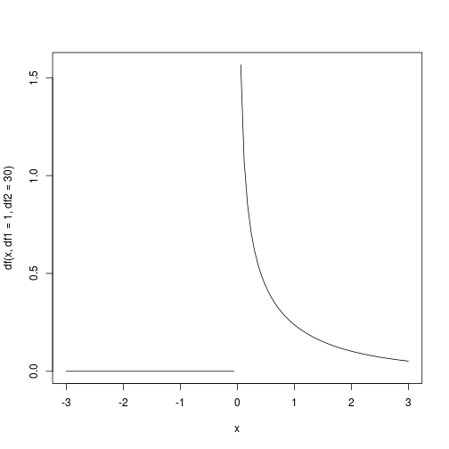

```r
curve(df(x, df1 = 1, df2 = 30), from = -3, to = 3)
```

- Looks like x can't be negative
  - this makes sense: you can't have negative variance

### Plotting it (2)

- Adjusting the x-axis

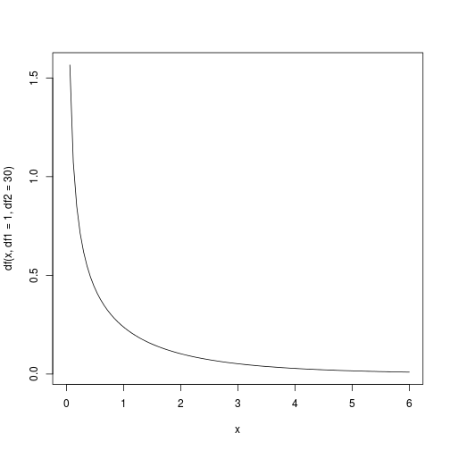

```r
curve(df(x, df1 = 1, df2 = 30), from = 0, to = 6)
```

### The F distribution

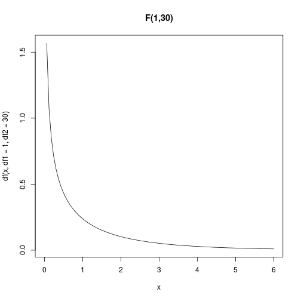

```r
curve(df(x, df1 = 1, df2 = 30), from = 0, to = 6, main = "F(1,30)")
```

### The F distribution (2)

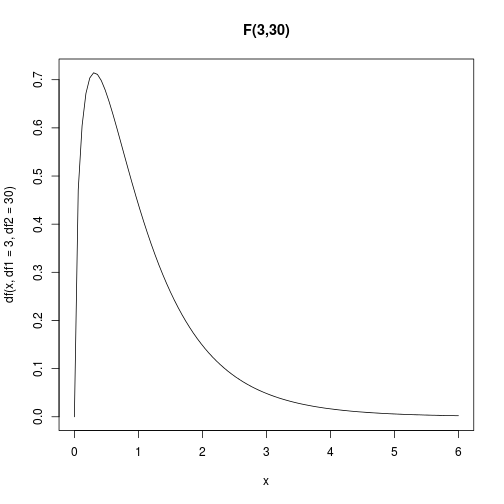

```r
curve(df(x, df1 = 3, df2 = 30), from = 0, to = 6, main = "F(3,30)")
```

### The F distribution (3)

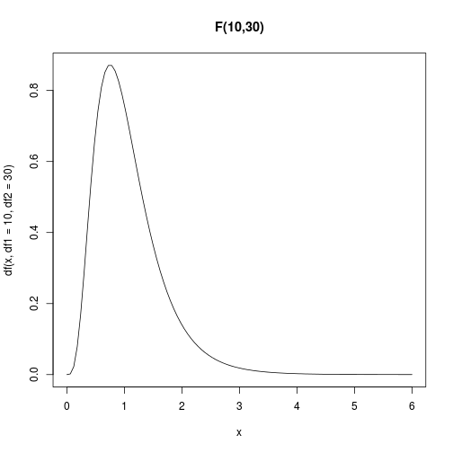

```r
curve(df(x, df1 = 10, df2 = 30), from = 0, to = 6, main = "F(10,30)")
```

### The F distribution (4)

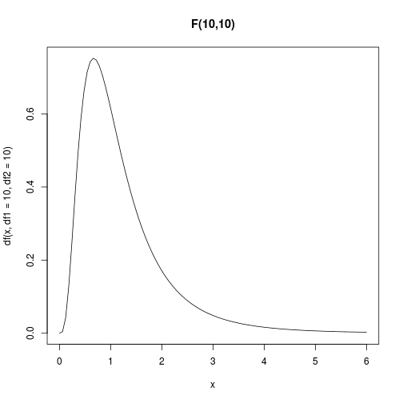

```r
curve(df(x, df1 = 10, df2 = 10), from = 0, to = 6, main = "F(10,10)")
```

### Finally finishing that ANOVA

- So, how extreme is our F-value given the \( H_0 \)?
- Let's get the p-value for our F-value

```r
(p_value <- 1 - pf(F_value, df1 = df_model, df2 = df_error))
```

```
[1] 0.4521
```

It's 1 - pf since pf gives you the probability for an F value to be smaller than the value given. We want the opposite. If \( p \leq .05 \), the effect of group is significant (spuriously in this case, since we know there was no effect).

### Can we just let R do it?

- Remember the formula format for the t-test command:

```r
summary(aov(formula = iq ~ group, data = iqdata))
```

```
            Df Sum Sq Mean Sq F value Pr(>F)
group        2    381     191    0.82   0.45
Residuals   27   6293     233
```

- `summary()` is necessary here to get the p-value
- This is just a convention in r

### A different way, using a package

```r
library(ez)
# ezANOVA wants a subject identifier, so let's generate one
# every row is a different subject, so we just need to make a new variable that numbers the rows
iqdata$subnum <- 1:30
```

### ezANOVA

```r
(iq_anova <- ezANOVA(iqdata, dv = iq, wid = subnum, between = group))
```

```
$ANOVA
  Effect DFn DFd      F      p p<.05     ges
1  group   2  27 0.8177 0.4521       0.05711

$`Levene's Test for Homogeneity of Variance`
  DFn DFd   SSn  SSd      F      p p<.05
1   2  27 52.68 1887 0.3769 0.6895
```

- Nice. What's `ges` and what is that second output?

### Effect size

- `ges` = generalised eta squared
- \( \eta^2 = \frac{SS_{model}}{SS_{total}} \)
- \( \eta_G^2 \) is \( \eta^2 \) with a correction for repeated measures designs (if applicable; we'll talk about those later)
- \( \eta^2 \) is an estimate of the relationship between variance explained by the ANOVA model and total variance in the data
- Compare this to Cohen's \( d \), another estimate of effect size:
  - \( d \) = \( \frac{\bar{x_1} - \bar{x_2}}{s} \)
  - Cohen's \( d \) is an estimate of how large a difference in means is (in standard deviations)
  - What is \( s \)? The standard deviation of the difference in means (from your sample)

### Levene's test for homogeneity of variance

```r
iq_anova[2] # get the second element of the list iq_anova
```

```
$`Levene's Test for Homogeneity of Variance`
  DFn DFd   SSn  SSd      F      p p<.05
1   2  27 52.68 1887 0.3769 0.6895
```

- When you perform an ANOVA, you make the assumption that the variances within each group are similar
  - For example, the IQs *within* the BU group should not be more variable than the IQs *within* the Soton and the Oxford groups
  - Levene's test compares the group variances
  - What's the test statistic for a test that compares variances? It's *F*!
  - The p-value tells you if the variances are significantly different between groups.

### Levene's test for homogeneity of variance

- You do not need Levene's test if you only have two independent groups (and ezANOVA won't do it then)
- If Levene's test is not significant, all is well
- If Levene's test is significant, you're violating the homogeneity of variance assumption
  - Not a big issue if the sample sizes are equal for all groups (balanced design)
  - If sample sizes aren't equal (unbalanced design) and the larger groups have higher variance, your ANOVA loses power
  - If sample sizes aren't equal and the larger groups have lower variance, your ANOVA becomes anti-conservative (\( \alpha \) increases)!

### Alternative: Bartlett's test

```r
bartlett.test(formula = iq ~ group, data = iqdata)
```

```
    Bartlett test of homogeneity of variances

data:  iq by group
Bartlett's K-squared = 0.5702, df = 2, p-value = 0.7519
```

- Bartlett's test is more sensitive to deviations from normality than Levene's test
- It's up to you which one you want to use (with ezANOVA, Levene's test is more convenient)

### What to do if Levene's or Bartlett's tests are significant

- If your group sizes are equal, nothing to worry about.
- If not:
  - Calculate the variance for each group and see if you're dealing with just a power issue or an \( \alpha \) issue
  - If the largest group variance is less than 4 times the smallest group variance, you're good.
  - If you have huge variance differences and there might be an \( \alpha \) issue:
  - Easiest solution: Fix the sample size issue (e.g. run more participants)!
  - Use linear mixed models (LMMs; more on that later)
  - Use specialised tests (this is SPSS's approach):
    - Welch's t-test (R has this test as `oneway.test()`)
    - Brown-Forsythe instead of ANOVA (R has this test in the `lawstats` package)
    - Post-hoc tests:
      - Games-Howell for unequal variance
      - Hochberg's GT2 for non-equal sample sizes

### The SPSS approach to statistics

- Throw as many obscure tests at the problem as you can
  - This is a sales strategy: “We need to buy SPSS since no other program has the Games-Howell test!”
- In reality, the standard ANOVA is remarkably robust to all but the most extreme violations of its assumptions
- Specialised tests often come at a huge cost in terms of power
- This doesn't mean that you shouldn't test the assumptions
  - But a simplistic strategy where you run one type of test if the assumption test is significant and another one if it isn't is not helpful
  - Take a good look at your data
  - Be aware of potential issues
  - Interpret the data accordingly.
  - Only use specialised and non-parametric tests as a last resort if your data massively violate the assumptions

### Just so we're clear

- Inflated \( \alpha \) is not harmless
- But “researcher degrees of freedom” inflate \( \alpha \) much more than all but the most extreme assumption violations
  - Stopping rules (test after every X participants, then stop as soon as you have a significant result)
  - Failing to report non-significant conditions
  - Failing to correct for multiple comparisons
- Don't let SPSS (or over-cautious textbooks) discourage you from running plain, simple ANOVAs
- Be honest and transparent about your data and how you collected them and you'll be fine.

### Reporting a one-way ANOVA

- Let's walk through it together
- I stole this data set from Andy Johnson
- We are investigating the effect of swearing on pain tolerance (see Stephens et al., 2009)
- Three groups: continuous use of swear word, neutral word, or no word whilst hand in cold water (DV = time until participant can't stand the pain and pulls hand from water)

```r
# open the data file (available on GitHub; don't forget to use setwd to set the working directory to where you put the file)
# setwd("C:/my_data/")
pain <- read.csv("pain.csv")
```

### Get an idea of what's in the file

```r
head(pain)
```

```
  X Swear.Condition Time.In.Cold.Water
1 1      Swear Word                 55
2 2      Swear Word                 64
3 3      Swear Word                 70
4 4      Swear Word                 60
5 5      Swear Word                 54
6 6      Swear Word                 66
```

```r
str(pain)
```

```
'data.frame':   60 obs. of  3 variables:
 $ X                 : int  1 2 3 4 5 6 7 8 9 10 ...
 $ Swear.Condition   : Factor w/ 3 levels "Neutral Word",..: 3 3 3 3 3 3 3 3 3 3 ...
 $ Time.In.Cold.Water: int  55 64 70 60 54 66 48 72 63 65 ...
```

### Is the design balanced?

```r
table(pain$Swear.Condition)
```

```
Neutral Word        Quiet   Swear Word
          20           20           20
```

### How is the DV distributed?

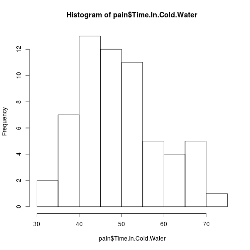

```r
hist(pain$Time.In.Cold.Water)
```

### Is the DV normal?

- Note: The raw DV does not have to be perfectly normal!
  - In fact, your alternative hypothesis is that it's not, since it is influenced by the treatment effect!
  - The error should be normal, though.
  - That is, the residual data that you get when you take the treatment effect out should be normal.
  - I'll show you how to test that in a second.

### Calculate means and SDs

```r
library(ez)
#for ez, we need a subject identifier so the function can tell if it's a between or within or mixed subject design
pain$subject <- factor(1:nrow(pain)) # nrow(pain) = number of observations. Each observation is a subject
(pain_stats <- ezStats(data = pain, dv = Time.In.Cold.Water, wid = subject, between =  Swear.Condition))
```

```
  Swear.Condition  N  Mean    SD  FLSD
1    Neutral Word 20 44.70 6.906 4.231
2           Quiet 20 45.75 5.711 4.231
3      Swear Word 20 60.45 7.323 4.231
```

```r
pain_stats
```

```
  Swear.Condition  N  Mean    SD  FLSD
1    Neutral Word 20 44.70 6.906 4.231
2           Quiet 20 45.75 5.711 4.231
3      Swear Word 20 60.45 7.323 4.231
```

- This gives you a nice overview of the group sizes, group means, and group variance/
- N is the group size. It's the same for each group, so your design is balanced.
- The mean is almost the same for the neutral and the quiet conditions, but higher in the swear word condition.
- SDs are quite similar, so it doesn't seem like the homogeneity of variance assumption is an issue
- Fisher's Least Significant Difference (FLSD): gives you an idea of the minimum effect size that would be significant in a t-test between any of these groups. This is just an estimate, not a replacement for the ANOVA and a post-hoc test.
  - Still useful to see which differences might be significant and which definitely aren't.

### Plot means

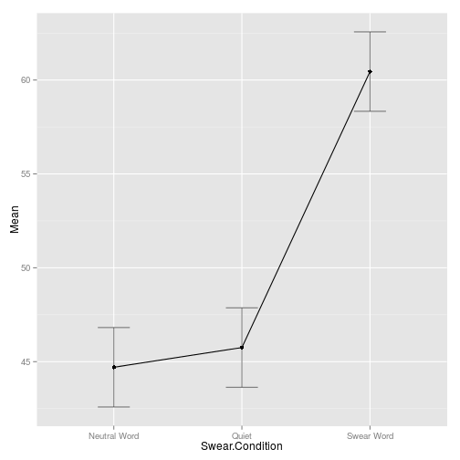

```r
ezPlot(data = pain, dv = Time.In.Cold.Water, wid = subject, between = Swear.Condition, x = Swear.Condition)
```

### Notes about the plot

- This plot is pretty good (better than anything SPSS gives you), but it is not perfect
- Discrete factors should be plotted as bars, not lines
- The error bars are Fisher's LSD, which is helpful in interpreting the differences, but unusual
- In a plot for publication, you would also want to change the axis labels
- I will give you a better function to use later
- For now, this is perfectly fine

### Perform the ANOVA

```r
pain_anova <- ezANOVA(data = pain, dv = Time.In.Cold.Water, wid = subject, between = Swear.Condition, return_aov = TRUE)
```

- Note the `return_aov = TRUE`.
- We need that because we want to look at the residuals later.

### Look at the results

```r
pain_anova$ANOVA
```

```
           Effect DFn DFd     F         p p<.05    ges
1 Swear.Condition   2  57 34.74 1.367e-10     * 0.5493
```

- Looks like there is a significant effect of swear condition.

```r
pain_anova$"Levene's Test for Homogeneity of Variance"
```

```
  DFn DFd   SSn   SSd     F      p p<.05
1   2  57 33.23 817.7 1.158 0.3213
```

- No issues with homogeneity of variance.

### Visually examine residuals

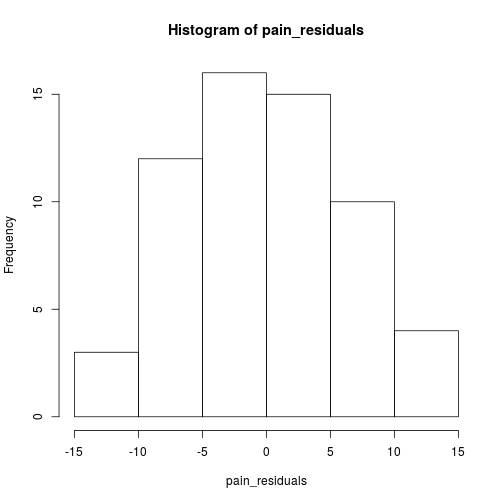

```r
pain_residuals <- resid(pain_anova$aov)
hist(pain_residuals)
```

- Looks quite normal.

### Quantile-Quantile Plot

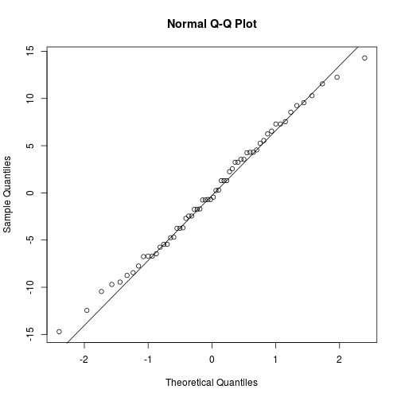

```r
qqnorm(pain_residuals)
qqline(pain_residuals)
```

- Plots the distribution of the variable in question against a hypothetical perfect normal distribution
- Deviations from the line are deviations from normality
- Our residuals are very slightly deviated. Is this an issue? Probably not.

### Formally test normality of residuals

- Shapiro-Wilk normality test

```r
shapiro.test(pain_residuals)
```

```
    Shapiro-Wilk normality test

data:  pain_residuals
W = 0.9918, p-value = 0.9596
```

- Not significant at all. No issues with non-normality.

### Perform post-hoc pairwise comparisons

```r
(pain_pairwise_p_values <- with(pain, pairwise.t.test(x = Time.In.Cold.Water, g = Swear.Condition, pool.sd = FALSE, p.adj = "bonferroni")))
```

```
    Pairwise comparisons using t tests with non-pooled SD

data:  Time.In.Cold.Water and Swear.Condition

           Neutral Word Quiet
Quiet      1            -
Swear Word 7.6e-08      7.9e-08

P value adjustment method: bonferroni
```

- These are the p-values for all the possible t-tests (Bonferroni correction applied)

### Perform post-hoc pairwise comparisons

- Better: Use Holm's correction instead of Bonferroni's correction for higher power

```r
(pain_pairwise_p_values <- with(pain, pairwise.t.test(x = Time.In.Cold.Water, g = Swear.Condition, pool.sd = FALSE, p.adj = "holm")))
```

```
    Pairwise comparisons using t tests with non-pooled SD

data:  Time.In.Cold.Water and Swear.Condition

           Neutral Word Quiet
Quiet      0.6          -
Swear Word 7.6e-08      7.6e-08

P value adjustment method: holm
```

### Perform post-hoc pairwise comparisons

```r
(pain_pairwise_p_values <- with(pain, pairwise.t.test(x = Time.In.Cold.Water, g = Swear.Condition, pool.sd = FALSE, p.adj = "holm")))
```

```
    Pairwise comparisons using t tests with non-pooled SD

data:  Time.In.Cold.Water and Swear.Condition

           Neutral Word Quiet
Quiet      0.6          -
Swear Word 7.6e-08      7.6e-08

P value adjustment method: holm
```

### Alternative: Tukey's HSD

```r
TukeyHSD(x = pain_anova$aov)
```

```
  Tukey multiple comparisons of means
    95% family-wise confidence level

Fit: aov(formula = formula(aov_formula), data = data)

$Swear.Condition
                         diff    lwr    upr  p adj
Quiet-Neutral Word       1.05 -4.035  6.135 0.8731
Swear Word-Neutral Word 15.75 10.665 20.835 0.0000
Swear Word-Quiet        14.70  9.615 19.785 0.0000
```

- Another way of correcting for multiple comparisons. Assumes equal variance.

### Now: report it

I'll show you how in Homework 3.